# An Introduction to data manipulation and ggplot

Jesús Calderón

January 2021

# Introduction

In this document, we will examine techniques for filtering and plotting data.

First, load the libraries that we will use and some data from gapminder.org:

```r
# Load libraries
library(tidyverse)
library(knitr)

# Data
library(gapminder) # no functions, only data
data(gapminder)
```

# Quick Views

## Glimpse

Function `glimpse()` affords a quick way of examining the structure (variables and their types) of a tibble, as well as a few sample values.

```r
glimpse(gapminder)
```

```
## Rows: 1,704
## Columns: 6
## $ country   <fct> "Afghanistan", "Afghanistan", "Afghanistan", "Afghanistan", ~
## $ continent <fct> Asia, Asia, Asia, Asia, Asia, Asia, Asia, Asia, Asia, Asia, ~
## $ year      <int> 1952, 1957, 1962, 1967, 1972, 1977, 1982, 1987, 1992, 1997, ~
## $ lifeExp   <dbl> 28.801, 30.332, 31.997, 34.020, 36.088, 38.438, 39.854, 40.8~
## $ pop       <int> 8425333, 9240934, 10267083, 11537966, 13079460, 14880372, 12~
## $ gdpPercap <dbl> 779.4453, 820.8530, 853.1007, 836.1971, 739.9811, 786.1134, ~
```

## Head

The function `head()` will display the first few rows of a tibble.

```r
gapminder %>%
  head()
```

```
## # A tibble: 6 x 6
##   country     continent  year lifeExp      pop gdpPercap
##   <fct>       <fct>     <int>   <dbl>    <int>     <dbl>
## 1 Afghanistan Asia       1952    28.8  8425333      779.
## 2 Afghanistan Asia       1957    30.3  9240934      821.
## 3 Afghanistan Asia       1962    32.0 10267083      853.
## 4 Afghanistan Asia       1967    34.0 11537966      836.
## 5 Afghanistan Asia       1972    36.1 13079460      740.
## 6 Afghanistan Asia       1977    38.4 14880372      786.
```

## Summary

The function `summary()` gives us basic statistics of each variable in our tibble.

```r
gapminder %>%
  summary()
```

```
##         country        continent        year         lifeExp
##  Afghanistan:  12   Africa  :624   Min.   :1952   Min.   :23.60
##  Albania    :  12   Americas:300   1st Qu.:1966   1st Qu.:48.20
##  Algeria    :  12   Asia    :396   Median :1980   Median :60.71
##  Angola     :  12   Europe  :360   Mean   :1980   Mean   :59.47
##  Argentina  :  12   Oceania : 24   3rd Qu.:1993   3rd Qu.:70.85
##  Australia  :  12                  Max.   :2007   Max.   :82.60
##  (Other)    :1632
##       pop              gdpPercap
##  Min.   :6.001e+04   Min.   :   241.2
##  1st Qu.:2.794e+06   1st Qu.:  1202.1
##  Median :7.024e+06   Median :  3531.8
##  Mean   :2.960e+07   Mean   :  7215.3
##  3rd Qu.:1.959e+07   3rd Qu.:  9325.5
##  Max.   :1.319e+09   Max.   :113523.1
##
```

# Data manipulation

## Summarise

A more powerful and flexible summary can be obtained with the function `summarise()`. Notice how we can call each column directly by its name in the tidyverse.

Notice that summarise takes a tibble and reduces its dimensions.

```r
gapminder %>%
  summarise(avg_life_expectncy = mean(lifeExp),
            median_life_expectancy = median(lifeExp),
            avg_gpd_per_capita = mean(gdpPercap),
            median_gdp_per_capita = median(gdpPercap)) %>%
  kable()
```

| avg_life_expectncy | median_life_expectancy | avg_gpd_per_capita | median_gdp_per_capita |
| --- | --- | --- | --- |
| 59.47444 | 60.7125 | 7215.327 | 3531.847 |

# Grouped Operations

We can operate by groups using `group_by()`. For example, we can obtain a grouped summary by combining `group_by()` and `summarise()`.

```r
summary_life_exp_by_continent <- gapminder %>%
        group_by(continent) %>%
        summarise(median_lifeExp = median(lifeExp),
                  iqr_lifeExp = IQR(lifeExp),
                  .groups = 'drop_last')

summary_life_exp_by_continent %>%
        kable(digits = 1)
```

| continent | median_lifeExp | iqr_lifeExp |
| --- | --- | --- |
| Africa | 47.8 | 12.0 |
| Americas | 67.0 | 13.3 |
| Asia | 61.8 | 18.1 |
| Europe | 72.2 | 5.9 |
| Oceania | 73.7 | 6.3 |

We can also group by several variables: we can calculate the average life expectancy by continent and year.

```r
life_exp_continent_year <- gapminder %>%
  group_by(continent, year) %>%
    summarise(avg_lifeExp = mean(lifeExp))

life_exp_continent_year %>%
  kable()
```

| continent | year | avg_lifeExp |
| --- | --- | --- |
| Africa | 1952 | 39.13550 |
| Africa | 1957 | 41.26635 |
| Africa | 1962 | 43.31944 |
| Africa | 1967 | 45.33454 |
| Africa | 1972 | 47.45094 |
| Africa | 1977 | 49.58042 |
| Africa | 1982 | 51.59287 |
| Africa | 1987 | 53.34479 |
| Africa | 1992 | 53.62958 |
| Africa | 1997 | 53.59827 |
| Africa | 2002 | 53.32523 |
| Africa | 2007 | 54.80604 |
| Americas | 1952 | 53.27984 |
| Americas | 1957 | 55.96028 |
| Americas | 1962 | 58.39876 |
| Americas | 1967 | 60.41092 |
| Americas | 1972 | 62.39492 |
| Americas | 1977 | 64.39156 |
| Americas | 1982 | 66.22884 |
| Americas | 1987 | 68.09072 |
| Americas | 1992 | 69.56836 |
| Americas | 1997 | 71.15048 |
| Americas | 2002 | 72.42204 |
| Americas | 2007 | 73.60812 |
| Asia | 1952 | 46.31439 |
| Asia | 1957 | 49.31854 |
| Asia | 1962 | 51.56322 |
| Asia | 1967 | 54.66364 |
| Asia | 1972 | 57.31927 |
| Asia | 1977 | 59.61056 |
| Asia | 1982 | 62.61794 |
| Asia | 1987 | 64.85118 |
| Asia | 1992 | 66.53721 |
| Asia | 1997 | 68.02052 |
| Asia | 2002 | 69.23388 |
| Asia | 2007 | 70.72848 |
| Europe | 1952 | 64.40850 |
| Europe | 1957 | 66.70307 |
| Europe | 1962 | 68.53923 |
| Europe | 1967 | 69.73760 |
| Europe | 1972 | 70.77503 |
| Europe | 1977 | 71.93777 |
| Europe | 1982 | 72.80640 |
| Europe | 1987 | 73.64217 |
| Europe | 1992 | 74.44010 |
| Europe | 1997 | 75.50517 |
| Europe | 2002 | 76.70060 |
| Europe | 2007 | 77.64860 |
| Oceania | 1952 | 69.25500 |
| Oceania | 1957 | 70.29500 |
| Oceania | 1962 | 71.08500 |
| Oceania | 1967 | 71.31000 |
| Oceania | 1972 | 71.91000 |
| Oceania | 1977 | 72.85500 |
| Oceania | 1982 | 74.29000 |
| Oceania | 1987 | 75.32000 |
| Oceania | 1992 | 76.94500 |
| Oceania | 1997 | 78.19000 |
| Oceania | 2002 | 79.74000 |
| Oceania | 2007 | 80.71950 |

**The table above is too long and can be better placed in an appendix.** Notice that we could do so by moving only the lines that display (not calculate) the tables to the end of the document.

Alternatively, when we have too much data, we can use a visual display such as a graph.

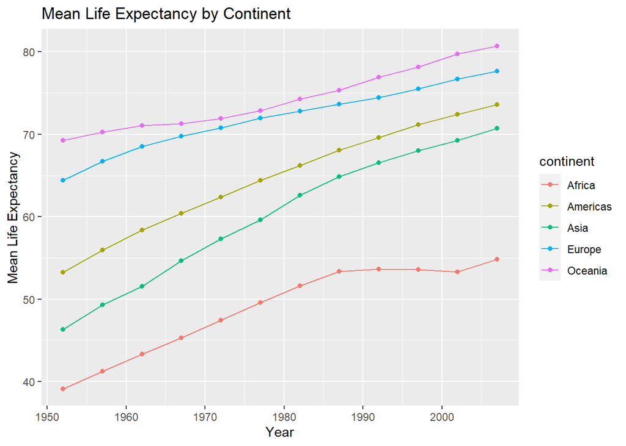

```r
life_exp_continent_year %>%
  ggplot(aes(x = year, y=avg_lifeExp, color = continent)) +
  geom_line() +
  geom_point() +
  labs(title ='Mean Life Expectancy by Continent',
       x = 'Year',
       y = 'Mean Life Expectancy')
```

# Filter

We can also filter some rows. For example, if we want to obtain only the observations from the Americas, we can write:

```r
americas_dt <- gapminder %>%
  filter(continent == 'Americas')

americas_dt %>%
  kable()
```

| country | continent | year | lifeExp | pop | gdpPercap |
| --- | --- | --- | --- | --- | --- |
| Argentina | Americas | 1952 | 62.485 | 17876956 | 5911.315 |
| Argentina | Americas | 1957 | 64.399 | 19610538 | 6856.856 |
| Argentina | Americas | 1962 | 65.142 | 21283783 | 7133.166 |
| Argentina | Americas | 1967 | 65.634 | 22934225 | 8052.953 |
| Argentina | Americas | 1972 | 67.065 | 24779799 | 9443.039 |
| Argentina | Americas | 1977 | 68.481 | 26983828 | 10079.027 |
| Argentina | Americas | 1982 | 69.942 | 29341374 | 8997.897 |
| Argentina | Americas | 1987 | 70.774 | 31620918 | 9139.671 |
| Argentina | Americas | 1992 | 71.868 | 33958947 | 9308.419 |
| Argentina | Americas | 1997 | 73.275 | 36203463 | 10967.282 |
| Argentina | Americas | 2002 | 74.340 | 38331121 | 8797.641 |
| Argentina | Americas | 2007 | 75.320 | 40301927 | 12779.380 |
| Bolivia | Americas | 1952 | 40.414 | 2883315 | 2677.326 |
| Bolivia | Americas | 1957 | 41.890 | 3211738 | 2127.686 |
| Bolivia | Americas | 1962 | 43.428 | 3593918 | 2180.973 |
| Bolivia | Americas | 1967 | 45.032 | 4040665 | 2586.886 |
| Bolivia | Americas | 1972 | 46.714 | 4565872 | 2980.331 |
| Bolivia | Americas | 1977 | 50.023 | 5079716 | 3548.098 |
| Bolivia | Americas | 1982 | 53.859 | 5642224 | 3156.510 |
| Bolivia | Americas | 1987 | 57.251 | 6156369 | 2753.691 |
| Bolivia | Americas | 1992 | 59.957 | 6893451 | 2961.700 |
| Bolivia | Americas | 1997 | 62.050 | 7693188 | 3326.143 |
| Bolivia | Americas | 2002 | 63.883 | 8445134 | 3413.263 |
| Bolivia | Americas | 2007 | 65.554 | 9119152 | 3822.137 |
| Brazil | Americas | 1952 | 50.917 | 56602560 | 2108.944 |
| Brazil | Americas | 1957 | 53.285 | 65551171 | 2487.366 |
| Brazil | Americas | 1962 | 55.665 | 76039390 | 3336.586 |
| Brazil | Americas | 1967 | 57.632 | 88049823 | 3429.864 |
| Brazil | Americas | 1972 | 59.504 | 100840058 | 4985.711 |
| Brazil | Americas | 1977 | 61.489 | 114313951 | 6660.119 |

[output cut: 270 more lines]

**Again, move long tables to the end.** Don’t leave them in the body of the text. A plot is a better option:

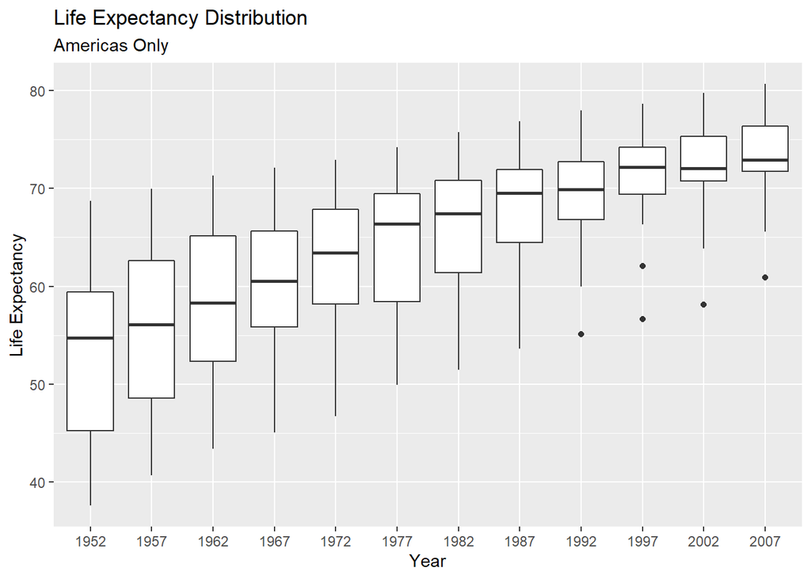

```r
americas_dt %>%
  ggplot(aes(x = as_factor(year), y = lifeExp)) +
  geom_boxplot() +
  labs(title = 'Life Expectancy Distribution',
       subtitle = 'Americas Only',
       x = 'Year',
       y = 'Life Expectancy')
```

# Facet Wrapping

We may also want to reproduce the chart above for all continents. We can do this easily with facetting, using the command `facet_wrap()`.

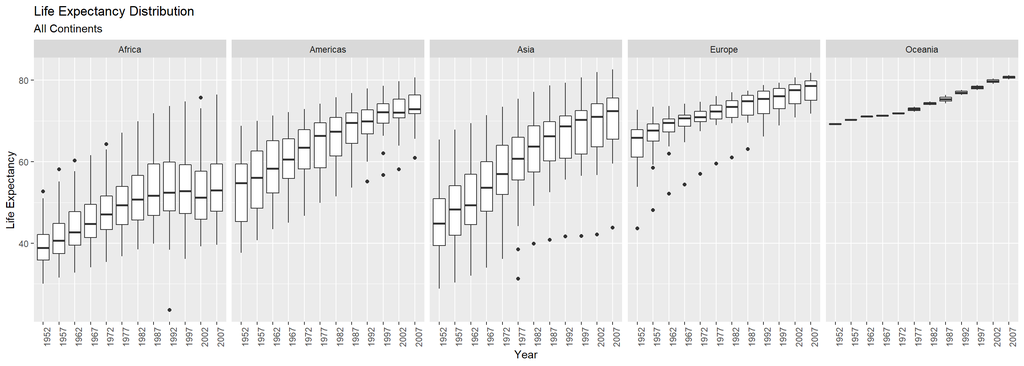

```r
gapminder %>%
  ggplot(aes(x = as_factor(year), y = lifeExp)) +
  geom_boxplot() +
  labs(title = 'Life Expectancy Distribution',
       subtitle = 'All Continents',
       x = 'Year',
       y = 'Life Expectancy') +
  facet_wrap(~continent, nrow = 1) +
  theme(axis.text.x = element_text(angle = 90))
```